# Introduction to BBC and iPlayer streaming data

The **BBC** is one of the oldest broadcasting organisations of the world. As a public service, its aim is to inform, educate, and entertain the UK population. Due to this broad mission, its key performance measures are not associated with financial profit but instead with how well it manages to engage the wider public with its program offering. To achieve its mission, it is particularly important to know which **customer segments** are interested in what content and how this drives their **engagement** with the BBC (often measured by how happy they are to pay for the TV licensing fees).

Traditionally, the BBC reached its audience through terrestrial broadcasting, first analogue and then digital, which made it difficult to monitor public engagement. This had to been done retrospectively by monitoring a relatively small sample of representative consumers who consented to having their TV-watching habits observed and recorded. More recently, the BBC launched a digital TV **streaming service**, the **BBC iPlayer**, which allows streaming BBC content on demand. Besides being a more convenient way to deliver content to the public, the streaming service allows the BBC to get a more detailed perspective of public engagement. In time, this should allow the BBC to better predict how different customer segments react to the programs it offers and become more effective in informing, educating, and entertaining them.

## Purpose of the project

The goal of this project is to use data mining techniques to gain a **data-based view** of BBC’s iPlayer **customers** and the content it provides.

i) We have an engagement based data and in the first step we will convert this to a user based data. Also we will engineer new features.

ii) In the second step we will create meaningful customer segments for the users of the BBC iPlayer. In this step you will use K-Means, K-Medoid and H-Clustering methods to determine meaningful clusters for iPlayer viewers.

The original data file contains information extracted from the BBC iPlayer database. The dataset was created by choosing approximately 10000 random viewers who watched something on iPlayer in January and then recording their viewing behaviour until the end of April. This means that customers who did not watch in January will not be in the dataset. Every row represents a viewing event. Given the way the data was created, during January the data is representative of what is watched on the iPlayer. After January the data is no longer representative as it is no longer a random sample of the people watching iPlayer content.

# Data Preprocessing

In this step we will first generate a **user-based database** which we will use to train clustering algorithms to identify meaningful clusters in the data.

Let's load the cleaned data and investigate what's in the data. See below for column descriptions.

```python
# Ignoring all warnings
import warnings
warnings.filterwarnings("ignore")

# Loading data
import pandas as pd
BBC_data = pd.read_csv("Results_Step1.csv")

# Describing loaded dataset
print(BBC_data.head())

# Glimpse columns
BBC_data.describe()
```

```
  user_id program_id series_id          genre      start_date_time  \
0  cd2006     b8fbf2    e0480e         Comedy  2017-01-19 22:17:04
1  cd2006     e2f113    933a1b        Factual  2017-02-14 19:12:36
2  cd2006     0e0916    b68e79  Entertainment  2017-01-18 21:05:11
3  cd2006     ca03b9    5d0813          Sport  2017-02-12 14:52:08
4  cd2006     cfe13a    eba31a         Comedy  2017-03-12 20:47:33

      streaming_id  prog_duration_min  time_viewed_min  duration_more_30s  \
0  1484864257965_1           1.850000         1.850000                  1
1  1487099603980_1           0.500000         0.499083                  1
2  1484773546557_1           1.366667         1.366667                  1
3  1486911176609_1           1.616667         1.616667                  1
4  1489351718862_1           8.500000         5.761667                  1

   time_viewed_more_5s  percentage_program_viewed  watched_more_60_percent  \
0                    1                   1.000000                        1
1                    1                   0.998167                        1
2                    1                   1.000000                        1
3                    1                   1.000000                        1
4                    1                   0.677843                        1

   month  day  hour  weekend time_of_day
0      1    5    22  weekday     Evening
1      2    3    19  weekday     Evening
2      1    4    21  weekday     Evening
3      2    1    14  weekend         Day
4      3    1    20  weekend     Evening
```

|  | prog_duration_min | time_viewed_min | duration_more_30s | time_viewed_more_5s | percentage_program_viewed | watched_more_60_percent | month | day | hour |
| --- | --- | --- | --- | --- | --- | --- | --- | --- | --- |
| count | 313256.000000 | 313256.000000 | 313256.0 | 313256.0 | 313256.000000 | 313256.000000 | 313256.000000 | 313256.000000 | 313256.000000 |
| mean | 49.633563 | 18.018207 | 1.0 | 1.0 | 0.462433 | 0.385988 | 2.398007 | 3.841417 | 15.378492 |
| std | 44.359907 | 23.119561 | 0.0 | 0.0 | 0.405144 | 0.486828 | 1.142645 | 2.047681 | 6.235505 |
| min | 0.500000 | 0.083333 | 1.0 | 1.0 | 0.000135 | 0.000000 | 1.000000 | 1.000000 | 0.000000 |
| 25% | 30.000000 | 1.017650 | 1.0 | 1.0 | 0.053571 | 0.000000 | 1.000000 | 2.000000 | 12.000000 |
| 50% | 45.000000 | 10.000650 | 1.0 | 1.0 | 0.313905 | 0.000000 | 2.000000 | 4.000000 | 17.000000 |
| 75% | 60.000000 | 28.009405 | 1.0 | 1.0 | 0.966617 | 1.000000 | 3.000000 | 6.000000 | 20.000000 |
| max | 720.000000 | 355.000000 | 1.0 | 1.0 | 1.000000 | 1.000000 | 4.000000 | 7.000000 | 23.000000 |

The column descriptions are as follows.

a) `user_id`: a unique identifier for the viewer

b) `program_id` and `series_id`: these identify the program and the series that the program belongs to

c) `genre`: the programme’s genre (e.g., drama, factual, news, sport, comedy, etc)

d) `start_date_time`: the streaming start date/time of the event

e) `Streaming id`: a unique identifier per streaming event

f) `prog_duration_min`: the program duration in minutes

g) `time_viewed_min`: how long the customer watched the program in minutes

h) `duration_more_30s`: equals 1 if the program duration is more than 30 seconds, equals 0 otherwise

h) `time_viewed_more_5s`: equals 1 if time_viewed is more than 5 seconds, equals 0 otherwise

i) `percentage_program_viewed`: percantage of the program viewed

j) `watched_more_60_percent`: equals 1 if more than 60% of the program is watched, equals 0 otherwise

k) `month, day, hour, weekend`: timing of the viewing

l) `time_of_day`: equals “Night” if the viewing occurs between 22 and 6am, "Day" if it occurs between 6AM and 14, “Afternoon” if the it occurs between 14 and 17, “Evening” otherwise.

Before we proceed, let's consider the usage in **January** only.

```python
# Filtering for January
BBC_data = BBC_data[BBC_data.month == 1]

# Checking for number of rows
BBC_data.shape[0]
```

```
94268
```

## Creating user-based data

Given the way the data is presented, we need to transform it to get a representation of the usage of each user. Hence, the dataset must be **user-based** rather than **usage-based**. In other words, each observation must be associated with a different user rather than a different viewing. This will then allow us to create new variables describing the **viewing habits** of each user.

### Feature Engineering

For this project, let's generate the following variables for each user.

1. Total number of shows watched.
2. Total time spent watching shows on iPlayer by each user in the data.

```python
# Creating the two new columns
User_based_data = BBC_data.groupby('user_id').agg({'user_id':'count','time_viewed_min':'sum'})
User_based_data = User_based_data.rename(columns={'user_id': 'noShows', 'time_viewed_min': 'total_Time'}).reset_index()

# Checking the new dataset
User_based_data.head()
```

|  | user_id | noShows | total_Time |
| --- | --- | --- | --- |
| 0 | 0001c6 | 2 | 16.679203 |
| 1 | 000c1a | 2 | 0.310333 |
| 2 | 001c53 | 2 | 1.866300 |
| 3 | 001d44 | 1 | 1.063617 |
| 4 | 002b2e | 31 | 534.355573 |

3. Proportion of shows watched during the weekend for each user.

```python
# Computing noShows for each user
userData2 = BBC_data.groupby(['user_id', 'weekend']).size().reset_index(name='noShows')
userData3 = userData2.groupby('user_id')['noShows'].transform('sum')

# Calculate the percentage (weight_pct) for each 'user_id' and 'weekend'
userData2['weight_pct'] = userData2['noShows'] / userData3

# Pivot the table to create columns for 'weekend' and 'weekday' with 'weight_pct' values
userData3 = userData2.pivot(index='user_id', columns='weekend', values='weight_pct').fillna(0).reset_index()

# Joining previous user_based_data with current dataset
User_data_all = pd.merge(User_based_data, userData3, on='user_id', how='left')

User_data_all.head()
```

|  | user_id | noShows | total_Time | weekday | weekend |
| --- | --- | --- | --- | --- | --- |
| 0 | 0001c6 | 2 | 16.679203 | 1.000000 | 0.000000 |
| 1 | 000c1a | 2 | 0.310333 | 1.000000 | 0.000000 |
| 2 | 001c53 | 2 | 1.866300 | 1.000000 | 0.000000 |
| 3 | 001d44 | 1 | 1.063617 | 0.000000 | 1.000000 |
| 4 | 002b2e | 31 | 534.355573 | 0.870968 | 0.129032 |

4. Proportion of shows watched during different times of day for each user.

```python
# Computing noShows for each user
userData2 = BBC_data.groupby(['user_id', 'time_of_day']).size().reset_index(name='noShows')
userData3 = userData2.groupby('user_id')['noShows'].transform('sum')

# Calculate the percentage (weight_pct) for each 'user_id' and 'time_of_day'
userData2['weight_pct'] = userData2['noShows'] / userData3

# Pivot the table to create columns for 'Day', 'Evening' and 'Night' with 'weight_pct' values
userData3 = userData2.pivot(index='user_id', columns='time_of_day', values='weight_pct').fillna(0).reset_index()

# Joining merged dataset created previously with new version
User_data_all = pd.merge(User_data_all, userData3, on='user_id', how='left')

User_data_all.head()
```

|  | user_id | noShows | total_Time | weekday | weekend | Afternoon | Day | Evening | Night |
| --- | --- | --- | --- | --- | --- | --- | --- | --- | --- |
| 0 | 0001c6 | 2 | 16.679203 | 1.000000 | 0.000000 | 0.0 | 0.000000 | 1.000000 | 0.000000 |
| 1 | 000c1a | 2 | 0.310333 | 1.000000 | 0.000000 | 0.0 | 1.000000 | 0.000000 | 0.000000 |
| 2 | 001c53 | 2 | 1.866300 | 1.000000 | 0.000000 | 0.0 | 1.000000 | 0.000000 | 0.000000 |
| 3 | 001d44 | 1 | 1.063617 | 0.000000 | 1.000000 | 0.0 | 0.000000 | 1.000000 | 0.000000 |
| 4 | 002b2e | 31 | 534.355573 | 0.870968 | 0.129032 | 0.0 | 0.096774 | 0.806452 | 0.096774 |

5. Proportion of shows watched in each genre by each user

```python
# Computing noShows for each user
userData2 = BBC_data.groupby(['user_id', 'genre']).size().reset_index(name='noShows')
userData3 = userData2.groupby('user_id')['noShows'].transform('sum')

# Calculate the percentage (weight_pct) for each 'user_id' and 'genre'
userData2['weight_pct'] = userData2['noShows'] / userData3

# Pivot the table to create columns for all genres with 'weight_pct' values
userData3 = userData2.pivot(index='user_id', columns='genre', values='weight_pct').fillna(0).reset_index()

# Joining merged dataset created previously with new version
User_data_all = pd.merge(User_data_all, userData3, on='user_id', how='left')

User_data_all.head()
```

|  | user_id | noShows | total_Time | weekday | weekend | Afternoon | Day | Evening | Night | Children | ... | Drama | Entertainment | Factual | Learning | Music | News | NoGenre | RelEthics | Sport | Weather |
| --- | --- | --- | --- | --- | --- | --- | --- | --- | --- | --- | --- | --- | --- | --- | --- | --- | --- | --- | --- | --- | --- |
| 0 | 0001c6 | 2 | 16.679203 | 1.000000 | 0.000000 | 0.0 | 0.000000 | 1.000000 | 0.000000 | 0.0 | ... | 0.000000 | 0.000000 | 0.000000 | 0.0 | 0.000000 | 1.000000 | 0.0 | 0.0 | 0.000000 | 0.0 |
| 1 | 000c1a | 2 | 0.310333 | 1.000000 | 0.000000 | 0.0 | 1.000000 | 0.000000 | 0.000000 | 0.0 | ... | 0.000000 | 0.000000 | 0.000000 | 0.0 | 0.000000 | 1.000000 | 0.0 | 0.0 | 0.000000 | 0.0 |
| 2 | 001c53 | 2 | 1.866300 | 1.000000 | 0.000000 | 0.0 | 1.000000 | 0.000000 | 0.000000 | 0.0 | ... | 0.000000 | 0.000000 | 0.000000 | 0.0 | 0.000000 | 1.000000 | 0.0 | 0.0 | 0.000000 | 0.0 |
| 3 | 001d44 | 1 | 1.063617 | 0.000000 | 1.000000 | 0.0 | 0.000000 | 1.000000 | 0.000000 | 0.0 | ... | 0.000000 | 1.000000 | 0.000000 | 0.0 | 0.000000 | 0.000000 | 0.0 | 0.0 | 0.000000 | 0.0 |
| 4 | 002b2e | 31 | 534.355573 | 0.870968 | 0.129032 | 0.0 | 0.096774 | 0.806452 | 0.096774 | 0.0 | ... | 0.322581 | 0.064516 | 0.419355 | 0.0 | 0.064516 | 0.032258 | 0.0 | 0.0 | 0.032258 | 0.0 |

5 rows × 21 columns

6. The average percentage of the program viewed by each user.

```python
# Computing average viewing percentage for each user
userData2 = BBC_data.groupby('user_id').agg({'percentage_program_viewed':'mean'}).rename(columns={'percentage_program_viewed':'mean_pct_program_viewed'}).reset_index()

# Merging with the User_data_all
User_data_all = pd.merge(User_data_all, userData2, on='user_id', how='left')

User_data_all.head()
```

|  | user_id | noShows | total_Time | weekday | weekend | Afternoon | Day | Evening | Night | Children | ... | Entertainment | Factual | Learning | Music | News | NoGenre | RelEthics | Sport | Weather | mean_pct_program_viewed |
| --- | --- | --- | --- | --- | --- | --- | --- | --- | --- | --- | --- | --- | --- | --- | --- | --- | --- | --- | --- | --- | --- |
| 0 | 0001c6 | 2 | 16.679203 | 1.000000 | 0.000000 | 0.0 | 0.000000 | 1.000000 | 0.000000 | 0.0 | ... | 0.000000 | 0.000000 | 0.0 | 0.000000 | 1.000000 | 0.0 | 0.0 | 0.000000 | 0.0 | 0.555973 |
| 1 | 000c1a | 2 | 0.310333 | 1.000000 | 0.000000 | 0.0 | 1.000000 | 0.000000 | 0.000000 | 0.0 | ... | 0.000000 | 0.000000 | 0.0 | 0.000000 | 1.000000 | 0.0 | 0.0 | 0.000000 | 0.0 | 0.001460 |
| 2 | 001c53 | 2 | 1.866300 | 1.000000 | 0.000000 | 0.0 | 1.000000 | 0.000000 | 0.000000 | 0.0 | ... | 0.000000 | 0.000000 | 0.0 | 0.000000 | 1.000000 | 0.0 | 0.0 | 0.000000 | 0.0 | 0.480605 |
| 3 | 001d44 | 1 | 1.063617 | 0.000000 | 1.000000 | 0.0 | 0.000000 | 1.000000 | 0.000000 | 0.0 | ... | 1.000000 | 0.000000 | 0.0 | 0.000000 | 0.000000 | 0.0 | 0.0 | 0.000000 | 0.0 | 0.012513 |
| 4 | 002b2e | 31 | 534.355573 | 0.870968 | 0.129032 | 0.0 | 0.096774 | 0.806452 | 0.096774 | 0.0 | ... | 0.064516 | 0.419355 | 0.0 | 0.064516 | 0.032258 | 0.0 | 0.0 | 0.032258 | 0.0 | 0.297209 |

5 rows × 22 columns

# Visualising user-based data

Next, we can visualise the information captured in the user-based data. Let's start with **correlations**.

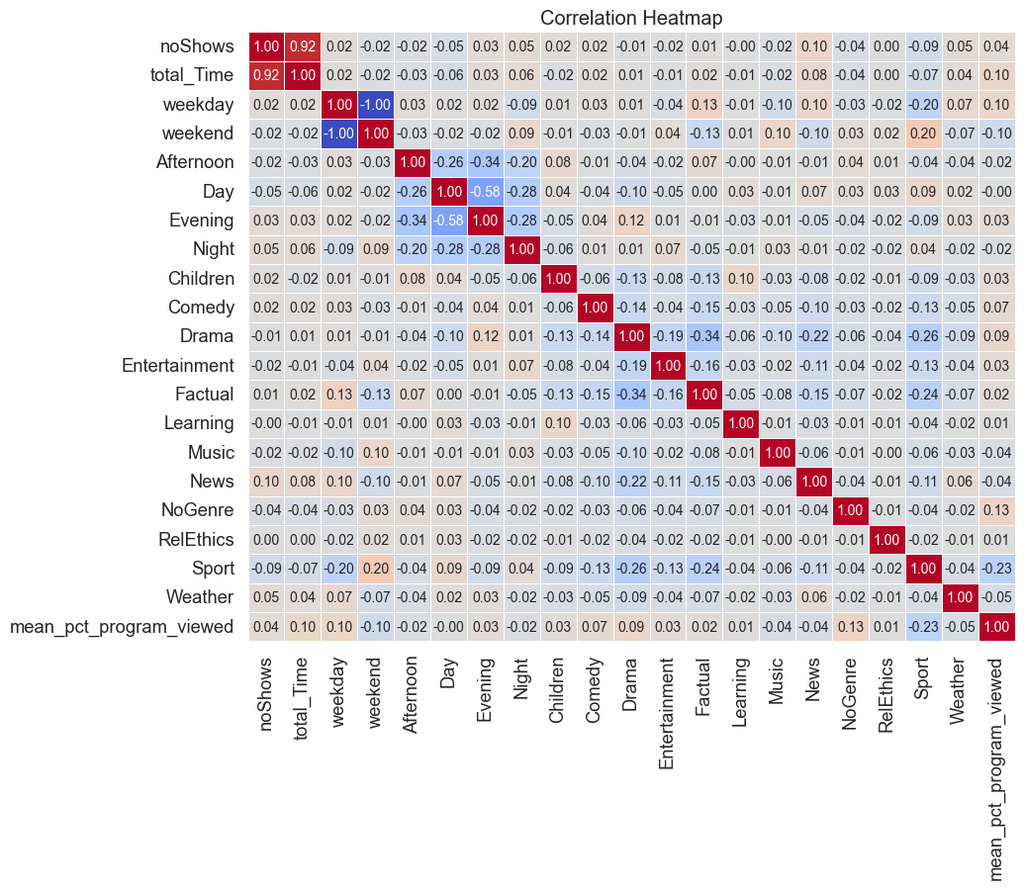

```python
import seaborn as sns
import matplotlib.pyplot as plt

# Drop the 'user_id' column
User_data_all = User_data_all.drop(columns=['user_id'])

# Calculate the correlation matrix
correlation_matrix = User_data_all.corr(method='pearson')

# Create a heatmap using seaborn (might need %matplotinline when knitting HTML)
plt.figure(figsize=(10, 8))
sns.set(font_scale=1.2)
sns.heatmap(correlation_matrix, annot=True, cmap='coolwarm', linewidths=0.5, fmt=".2f", annot_kws={"size": 10}, cbar=False)
plt.title('Correlation Heatmap')
plt.show()
```

The following are the **most correlated** variables in the dataset:

1. total_Time & noShows (0.92)
2. Day & Evening (-0.58)
3. Afternoon & Evening (-0.34)
4. Day & Night (-0.28)
5. Drama & Factual (-0.34)
6. Drama & News (-0.22)
7. Drama & Sport (-0.26)
8. Sport & Factual (-0.24)
9. Sport & weekday/weekend (+- 0.20)

When clustering, the goal is to select a set of variables that are **least correlated** with each other. In fact, the goal is to construct a representation of the object (the user in this case) that is as **comprehensive** as possible. Hence, we would probably have to choose between one of the two variables in each of the pairs listed, since the correlation between the variables in the pairs is significantly high. In fact, we would probably pick only one between **total_Time** and **noShows**, since the correlation between the two is 0.92, meaning that either of the two fully explains the behaviour of the other variable. The same applies to the Day & Evening pair (-0.58 correlation coefficient).

Let's now investigate the distributions for both **noShows** and **total_Time**

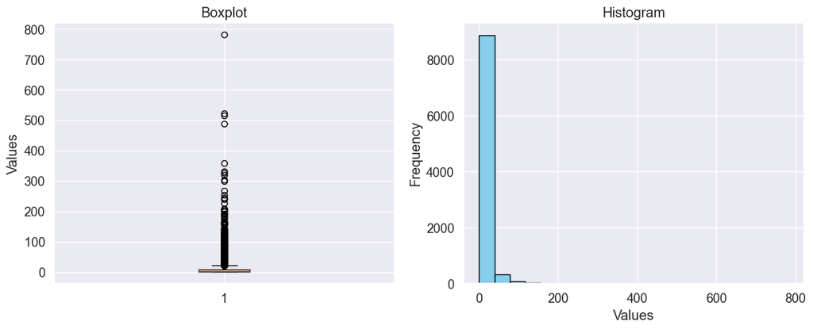

```python
# Plotting noShows
# Create a figure with two subplots: one for the boxplot and one for the histogram
fig, (ax1, ax2) = plt.subplots(1, 2, figsize=(12, 5))

# Plot the boxplot on the first subplot (ax1)
ax1.boxplot(User_data_all.noShows)
ax1.set_title('Boxplot')
ax1.set_ylabel('Values')

# Plot the histogram on the second subplot (ax2)
ax2.hist(User_data_all.noShows, bins=20, color='skyblue', edgecolor='black')
ax2.set_title('Histogram')
ax2.set_xlabel('Values')
ax2.set_ylabel('Frequency')

# Adjust the spacing between subplots
plt.tight_layout()

# Show the plots
plt.show()
```

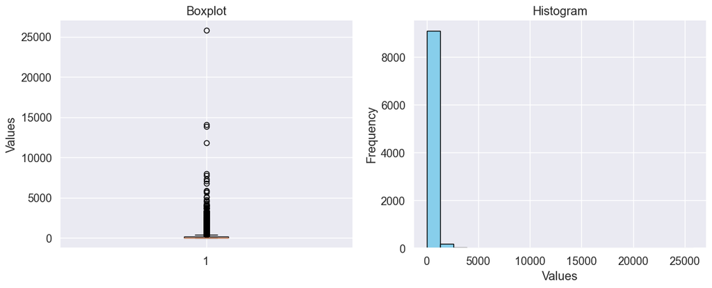

```python
# Plotting total_Time
# Create a figure with two subplots: one for the boxplot and one for the histogram
fig, (ax1, ax2) = plt.subplots(1, 2, figsize=(12, 5))

# Plot the boxplot on the first subplot (ax1)
ax1.boxplot(User_data_all.total_Time)
ax1.set_title('Boxplot')
ax1.set_ylabel('Values')

# Plot the histogram on the second subplot (ax2)
ax2.hist(User_data_all.total_Time, bins=20, color='skyblue', edgecolor='black')
ax2.set_title('Histogram')
ax2.set_xlabel('Values')
ax2.set_ylabel('Frequency')

# Adjust the spacing between subplots
plt.tight_layout()

# Show the plots
plt.show()
```

As shown by the boxplots and histograms, both distributions are heavily skewed with a significant number of outliers. This could hijack our clustering algorithms, especially mean-based algorithms such as K-means since the computation of the mean-center of each cluster is highly sensitive to outliers.

## Delete infrequent users

For our clustering to be as robust and informative as possible, we need to keep only frequent users. Hence, we are going to drop users who have a total view time lower than 5 minutes and users who viewed fewer than 5 programs.

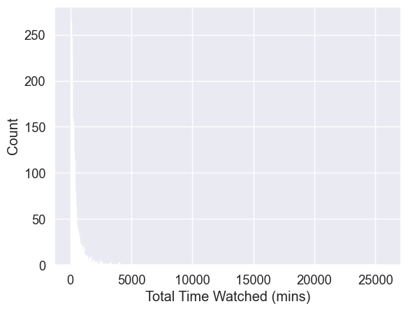

```
<class 'pandas.core.frame.DataFrame'>
Int64Index: 3625 entries, 4 to 9349
Data columns (total 21 columns):
 #   Column                   Non-Null Count  Dtype
---  ------                   --------------  -----
 0   noShows                  3625 non-null   int64
 1   total_Time               3625 non-null   float64
 2   weekday                  3625 non-null   float64
 3   weekend                  3625 non-null   float64
 4   Afternoon                3625 non-null   float64
 5   Day                      3625 non-null   float64
 6   Evening                  3625 non-null   float64
 7   Night                    3625 non-null   float64
 8   Children                 3625 non-null   float64
 9   Comedy                   3625 non-null   float64
 10  Drama                    3625 non-null   float64
 11  Entertainment            3625 non-null   float64
 12  Factual                  3625 non-null   float64
 13  Learning                 3625 non-null   float64
 14  Music                    3625 non-null   float64
 15  News                     3625 non-null   float64
 16  NoGenre                  3625 non-null   float64
 17  RelEthics                3625 non-null   float64
 18  Sport                    3625 non-null   float64
 19  Weather                  3625 non-null   float64
 20  mean_pct_program_viewed  3625 non-null   float64
dtypes: float64(20), int64(1)
memory usage: 623.0 KB
```

```python
# Filtering for frequent users
user_data_red = User_data_all[(User_data_all['total_Time'] >= 5) & (User_data_all['noShows'] >= 5)]

# Create a histogram of total_Time
plt.hist(user_data_red['total_Time'], bins=range(0, round(max(user_data_red['total_Time']) + 25), 25))
plt.xlabel('Total Time Watched (mins)')
plt.ylabel('Count')
plt.show()

# Display summary information about 'user_data_red'
user_data_red.info()
```

# Clustering with K-Means

Now we are ready to find clusters in the BBC iPlayer viewers. We will start with the **K-Means** algorithm. However, before doing so, we will have to go take some preliminary steps.

First of all, we will drop the variables we will not use to cluster the data. For instance, we will not include `user_id` and highly correlated variables, such as `noShows`.

```python
# Drop variables we will not use
user_data_red = user_data_red.drop(columns=['noShows'])
```

Now, in order to reduce the effect of outliers of `total_Time` on the clusters, we will take the **logarithm** of it and include that in the clustering algorithm.

```python
# Transforming total_Time in its logarithm
import numpy as np
user_data_red['total_Time'] = np.log(user_data_red['total_Time'])
```

Last, we need to **scale** the variables we use to cluster the users. There are multiple reasons why we would want to scale the variables before running a clustering algorithm. For instance, since K-Means clustering is based on Euclidian distances between points, variables with higher magnitudes would affect the clustering more than those with lower magnitude. Hence, in order to assign **equal weight** (relevance) to all variables, we need to scale them.

```python
# Scaling dataset features
from sklearn.preprocessing import StandardScaler
scaler = StandardScaler()
scaled_user_red = scaler.fit_transform(user_data_red)
```

We are now ready to train a K-Means clustering model on the scaled data. We will start by running the algorithm with the **K** **hyperparameter** set at **2**.

```python
# Importing needed libraries
from sklearn.cluster import KMeans
kmeans = KMeans(n_clusters = 2, random_state = 0)
kmeans.fit(scaled_user_red)

# Adding clusters to the dataframe
scaled_user_red = pd.DataFrame(scaled_user_red, columns=user_data_red.columns)
scaled_user_red['cluster'] = kmeans.labels_
scaled_user_red.head()
```

|  | total_Time | weekday | weekend | Afternoon | Day | Evening | Night | Children | Comedy | Drama | ... | Factual | Learning | Music | News | NoGenre | RelEthics | Sport | Weather | mean_pct_program_viewed | cluster |
| --- | --- | --- | --- | --- | --- | --- | --- | --- | --- | --- | --- | --- | --- | --- | --- | --- | --- | --- | --- | --- | --- |
| 0 | 0.729406 | 0.788559 | -0.788559 | -0.796064 | -0.545330 | 1.184218 | -0.287200 | -0.273237 | -0.194105 | 0.072805 | ... | 0.658802 | -0.134312 | 0.749251 | -0.394827 | -0.124232 | -0.13967 | -0.216624 | -0.344646 | -0.792373 | 0 |
| 1 | 0.578495 | 0.338300 | -0.338300 | 0.021888 | 0.757377 | -0.144897 | -0.694193 | -0.273237 | -0.576376 | -0.981034 | ... | 0.188013 | -0.134312 | -0.259267 | 2.211240 | -0.124232 | -0.13967 | -0.102439 | 0.563929 | 0.029132 | 0 |
| 2 | -1.479165 | 1.268834 | -1.268834 | -0.796064 | -0.902237 | 0.999619 | 0.357204 | -0.273237 | 0.904924 | -0.981034 | ... | -0.009209 | -0.134312 | -0.259267 | 1.514791 | -0.124232 | -0.13967 | 0.380250 | -0.344646 | -1.750631 | 0 |
| 3 | -0.340654 | 0.570934 | -0.570934 | -0.796064 | -0.902237 | 1.817130 | -0.694193 | -0.273237 | -0.576376 | -0.776853 | ... | 0.976902 | -0.134312 | -0.259267 | -0.574556 | -0.124232 | 2.53043 | -0.424232 | -0.344646 | -1.130919 | 0 |
| 4 | -0.241166 | -1.522769 | 1.522769 | 1.248816 | -0.441233 | 0.182108 | -0.694193 | -0.273237 | -0.576376 | 1.673324 | ... | -0.255737 | -0.134312 | -0.259267 | -0.574556 | -0.124232 | -0.13967 | -0.424232 | -0.344646 | -1.461944 | 1 |

5 rows × 21 columns

### Cluster Centers

We are now going to plot the **normalised cluster centers** along each dimension in the dataset, so that we get a sense of what are the main features of the two clusters calculated.

```python
# Creating a DataFrame for cluster centers
cluster_centers = pd.DataFrame(kmeans.cluster_centers_, columns = scaled_user_red.columns[:20])
cluster_centers['cluster'] = np.array([0, 1])
```

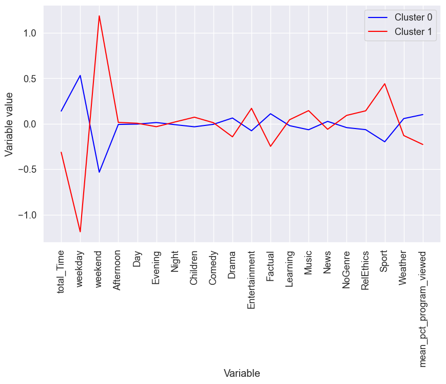

```python
# Visualising cluster centers
plt.figure(figsize=(10, 6))
plt.plot(cluster_centers.columns[:20], cluster_centers.iloc[0, :20], color='blue')
plt.plot(cluster_centers.columns[:20], cluster_centers.iloc[1, :20], color='red')
plt.xticks(rotation = 90)
plt.xlabel('Variable')
plt.ylabel('Variable value')
plt.legend(['Cluster 0', 'Cluster 1'])
plt.show()
```

This plot gives us a first piece of information on how well the algorithm performed in computing the clusters. At first glance, we can say that the algorithm manage to separate the clusters fairly well. In fact, the difference between the centers is significant along many dimensions, such as `total_Time`, `weekday`, `weekend`, `Drama`, `Entertainment`, `Factual`, `Music`, `RelEthics`, `Sport`, `Weather` and `mean_pct_program_viewed`. However, in order to have a complete overview of the performance, we must visualise the data and judge how well the algorithm separates it in two clusters.

### Clusters vs Variables

We are now going to visualise how the clusters are distributed by plotting the observations using `total_Time` and `weekend` variables. This will allow us to understand which variable plays the biggest role in separating the clusters.

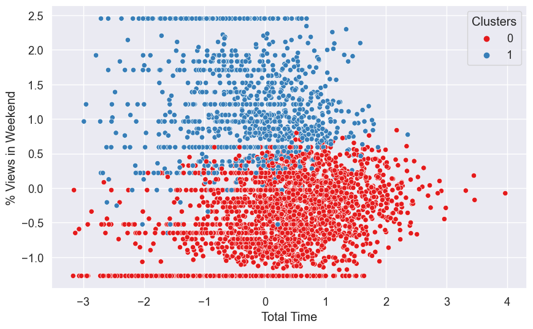

```python
# Plotting total_Time and weekend
import seaborn as sns
plt.figure(figsize=(10, 6))
sns.scatterplot(data=scaled_user_red, x='total_Time', y='weekend', hue='cluster', palette='Set1')

# Add labels and legend
plt.xlabel('Total Time')
plt.ylabel('% Views in Weekend')
plt.legend(title='Clusters')

# Show the plot
plt.show()
```

As shown by the plot, the variable along which the two clusters are most separated is `weeekend`. In fact, if we were to project the two clusters on the x-axis only, we would get a significant overlap between the two clusters. Conversely, if we were to do so on the y-axis (`weekend`), we could see a much better separation (much less overlap).

### Clusters vs PCA components

In order to make the visualisation tidier and more clear, we are going to plot the data using PCA (Principal Component Analysis). We are going to extract the first two PC in order to compare the visualisation with the one we built using `total_Time` and `weekend`.

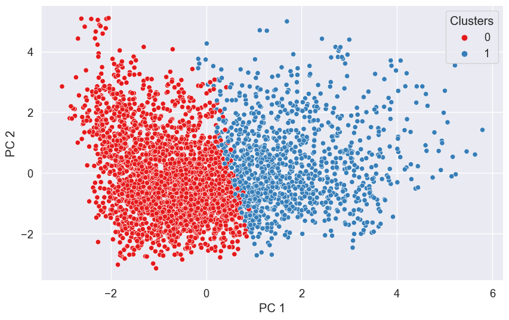

```python
# Running PCA algorithm with 2 PCs
from sklearn.decomposition import PCA
pca = PCA(n_components = 2)
pca.fit(scaled_user_red.iloc[:,:-1])

# Obtaining first 2 PCs
X_pca = pca.transform(scaled_user_red.iloc[:,:-1])
X_pca = {'PC 1': X_pca[:, 0], 'PC 2': X_pca[:, 1], 'cluster': scaled_user_red.cluster}
X_pca = pd.DataFrame(X_pca)

# Plotting clusters along 2 PCs
plt.figure(figsize=(10, 6))
sns.scatterplot(data=X_pca, x='PC 1', y='PC 2', hue='cluster', palette='Set1')

# Add labels and legend
plt.xlabel('PC 1')
plt.ylabel('PC 2')
plt.legend(title='Clusters')

# Show the plot
plt.show()
```

As shown by the plot, the two clusters are much better separated. This happens because the PCA algorithm "produces" dimensions along which the data variance is maximised. In other words, `PC 1` and `PC 2`are the two dimensions that capture the **most variance** in the data. Hence, it is clear that they are the two dimensions that best separate the clusters.

### Clusters with PCA components without log transform

To improve our understanding of how **outliers** and **correlated variables** can affect the K-Means clustering, we will run the K-Means algorithm again including the `noShows` variable and keeping the original version of the `total_Time` variable.

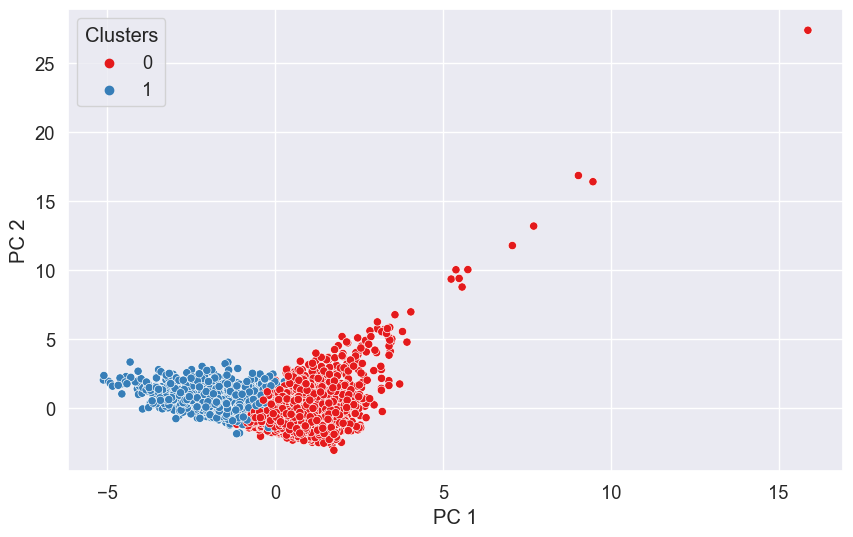

```python
# Adding noShows and original total_Time to scale_user_red
user_data_red = User_data_all[(User_data_all['total_Time'] >= 5) & (User_data_all['noShows'] >= 5)]

# Scaling the dataset
scaler = StandardScaler()
scaled_user_red = scaler.fit_transform(user_data_red)

# Running K-Means algorithm
kmeans = KMeans(n_clusters = 2, random_state = 0)
kmeans.fit(scaled_user_red)
scaled_user_red = pd.DataFrame(scaled_user_red, columns=user_data_red.columns)
scaled_user_red['cluster'] = kmeans.labels_

# Running PCA algorithm
pca = PCA(n_components = 2)
pca.fit(scaled_user_red.iloc[:,:-1])
X_pca = pca.transform(scaled_user_red.iloc[:,:-1])
X_pca = {'PC 1': X_pca[:, 0], 'PC 2': X_pca[:, 1], 'cluster': scaled_user_red.cluster}
X_pca = pd.DataFrame(X_pca)

# Plotting clusters along 2 PCs
plt.figure(figsize=(10, 6))
sns.scatterplot(data=X_pca, x='PC 1', y='PC 2', hue='cluster', palette='Set1')

# Add labels and legend
plt.xlabel('PC 1')
plt.ylabel('PC 2')
plt.legend(title='Clusters')

# Show the plot
plt.show()
```

As we can see, `total_Time` was factored in when computing the `PC 1` since the presence of outliers deceives the selection of the dimension along which the variance is explained the most. Besides causing visualisation issues, the presence of outliers also deceives the computation of the cluster centers and, consequently, of the clusters themselves.

## Elbow Chart

So far, we have run our K-Means clustering algorithm by setting the `K` parameter at 2. However, the decision in real settings is usually much more complicated. In fact, the number of clusters is usually set to minimise the total distance between the datapoints and their cluster centers. However, we are also aware that minimising the "total within distance" is an **unconstrained optimisation** problem. Hence, we have to make trade-offs between the number of clusters and the **"total within distance"** and find the optimal combination of the two. One of the simplest yet best tools to use for this task is the **elbow chart**.

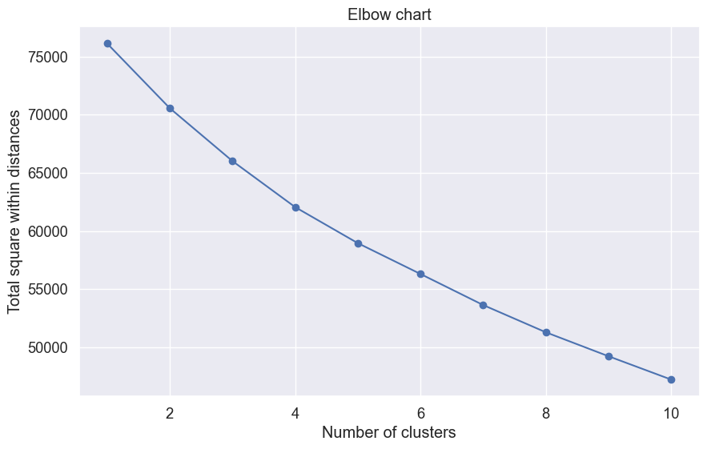

```python
# Take log total_Time
scaler = StandardScaler()
scaled_user_red['total_Time'] = scaler.fit_transform(np.array(np.log(user_data_red['total_Time'])).reshape(-1, 1))

# Create function to run K-Means and return "total within distance"
def kmeans_inertia(K):
    kmeans = KMeans(n_clusters = K, random_state = 0)
    kmeans.fit(scaled_user_red.iloc[:, :-1])
    return kmeans.inertia_

# Vectorise "kmeans_inertia" and run it on set of parameters
kmeans_inertia_vec = np.vectorize(kmeans_inertia)
K_set = np.linspace(1,10,10).astype(np.int32)
within_distances = kmeans_inertia_vec(K_set)

# Plotting elbow chart
plt.figure(figsize = (10, 6))
plt.plot(K_set, within_distances, marker='o', color='b')
plt.xlabel('Number of clusters')
plt.ylabel('Total square within distances')
plt.title('Elbow chart')
plt.show()
```

As shown in the elbow chart, there is a slight elbow at **4 clusters**, signaling that the decrease in "total within distance" is much less when going beyond 4 clusters. We are now going to compare this method with the **silhouette analysis** method.

## Silhouette analysis

The **silhouette value** is a measure of how similar an object is to its own cluster (*cohesion*) compared to other clusters (*separation*). The silhouette ranges from −1 to +1, where a high value indicates that the object is well matched to its own cluster and poorly matched to neighboring clusters. If most objects have a high value, then the clustering configuration is appropriate. If many points have a low or negative value, then the clustering configuration may have too many or too few clusters. In the plot below, we show the **average silhouette value** as a function of the number of clusters.

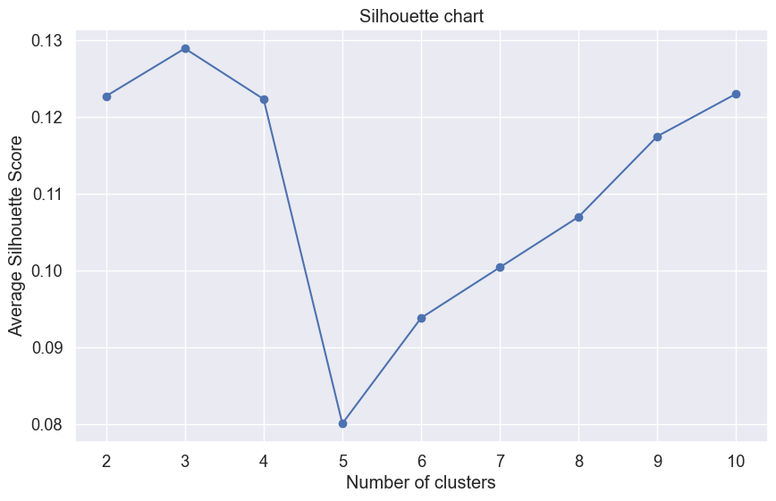

```python
# Import needed packages
from sklearn.metrics import silhouette_score

# Creating "silhouette" function
def silhouette(K):
    kmeans = KMeans(n_clusters = K, random_state = 0)
    kmeans.fit(scaled_user_red.iloc[:, :-1])
    cluster_labels = kmeans.labels_
    silhouette_avg = silhouette_score(scaled_user_red, cluster_labels)
    return silhouette_avg

# Vectorise "silhouette" and run it on set of parameters
silhouette_vec = np.vectorize(silhouette)
K_set = np.linspace(2,10,9).astype(np.int32)
silhouette_avg_scores = silhouette_vec(K_set)

# Plotting elbow chart
plt.figure(figsize = (10, 6))
plt.plot(K_set, silhouette_avg_scores, marker='o', color='b')
plt.xlabel('Number of clusters')
plt.ylabel('Average Silhouette Score')
plt.title('Silhouette chart')
plt.show()
```

## Comparing K-Means with different K

For simplicity, we are now going to focus on lower values. We will plot **centers** and **cluster sizes** for models with K = 3, 4, 5. Therefore, we are going to compare the three different scenarios based on these two pieces of information and evaluate which of the three scenarios is more plausible.

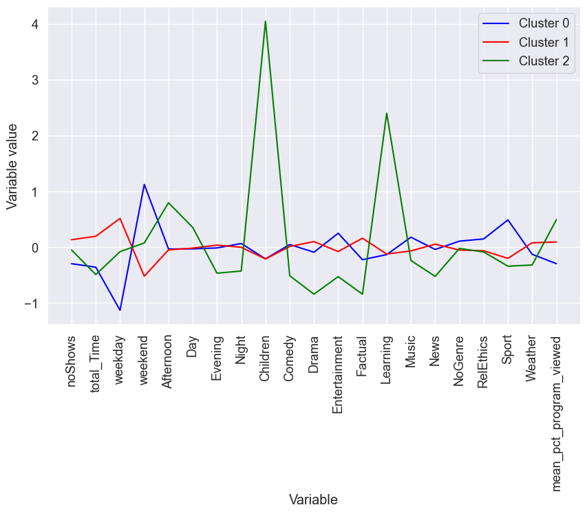

```
[1076 2372  177]
```

```python
# K=3
# Run KMeans algo
kmeans = KMeans(n_clusters = 3, random_state = 0)
kmeans.fit(scaled_user_red.iloc[:, :-1])

# Create a DataFrame for cluster centers
cluster_centers = pd.DataFrame(kmeans.cluster_centers_, columns = scaled_user_red.columns[:21])
cluster_centers['cluster'] = np.array([0, 1, 2])

# Visualise cluster centers
plt.figure(figsize = (10, 6))
plt.plot(cluster_centers.columns[:21], cluster_centers.iloc[0, :21], color='blue')
plt.plot(cluster_centers.columns[:21], cluster_centers.iloc[1, :21], color='red')
plt.plot(cluster_centers.columns[:21], cluster_centers.iloc[2, :21], color='green')
plt.xticks(rotation = 90)
plt.xlabel('Variable')
plt.ylabel('Variable value')
plt.legend(['Cluster 0', 'Cluster 1', 'Cluster 2'])
plt.show()

# Print cluster sizes
print(np.bincount(kmeans.labels_))
```

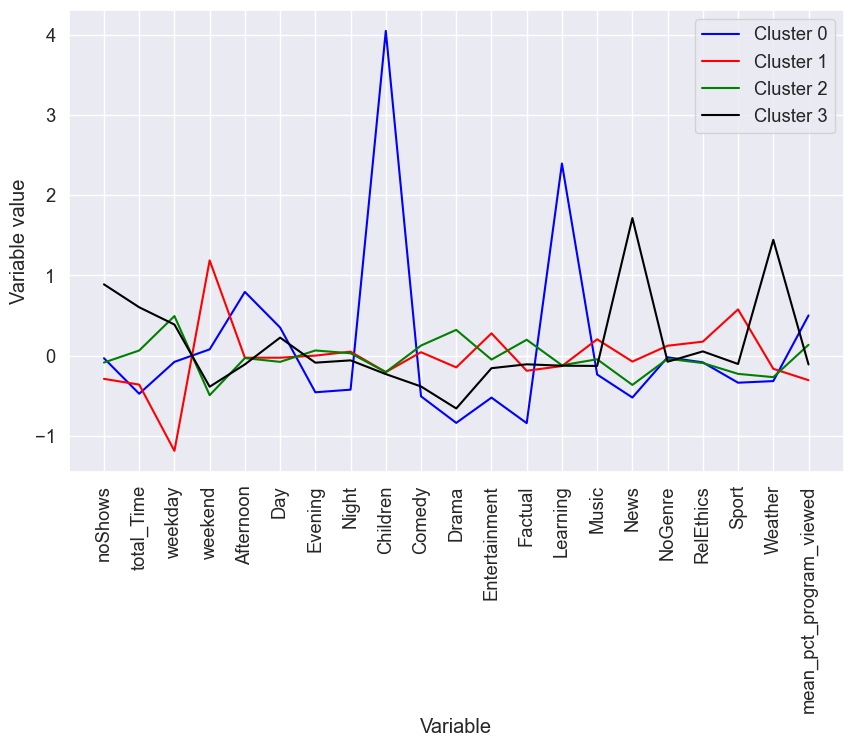

```
[ 178  972 1961  514]
```

```python
# K=4
# Run KMeans algo
kmeans = KMeans(n_clusters = 4, random_state = 0)
kmeans.fit(scaled_user_red.iloc[:, :-1])

# Create a DataFrame for cluster centers
cluster_centers = pd.DataFrame(kmeans.cluster_centers_, columns = scaled_user_red.columns[:21])
cluster_centers['cluster'] = np.array([0, 1, 2, 3])

# Visualise cluster centers
plt.figure(figsize = (10, 6))
plt.plot(cluster_centers.columns[:21], cluster_centers.iloc[0, :21], color='blue')
plt.plot(cluster_centers.columns[:21], cluster_centers.iloc[1, :21], color='red')
plt.plot(cluster_centers.columns[:21], cluster_centers.iloc[2, :21], color='green')
plt.plot(cluster_centers.columns[:21], cluster_centers.iloc[3, :21], color='black')
plt.xticks(rotation = 90)
plt.xlabel('Variable')
plt.ylabel('Variable value')
plt.legend(['Cluster 0', 'Cluster 1', 'Cluster 2', 'Cluster 3'])
plt.show()

# Print cluster sizes
print(np.bincount(kmeans.labels_))
```

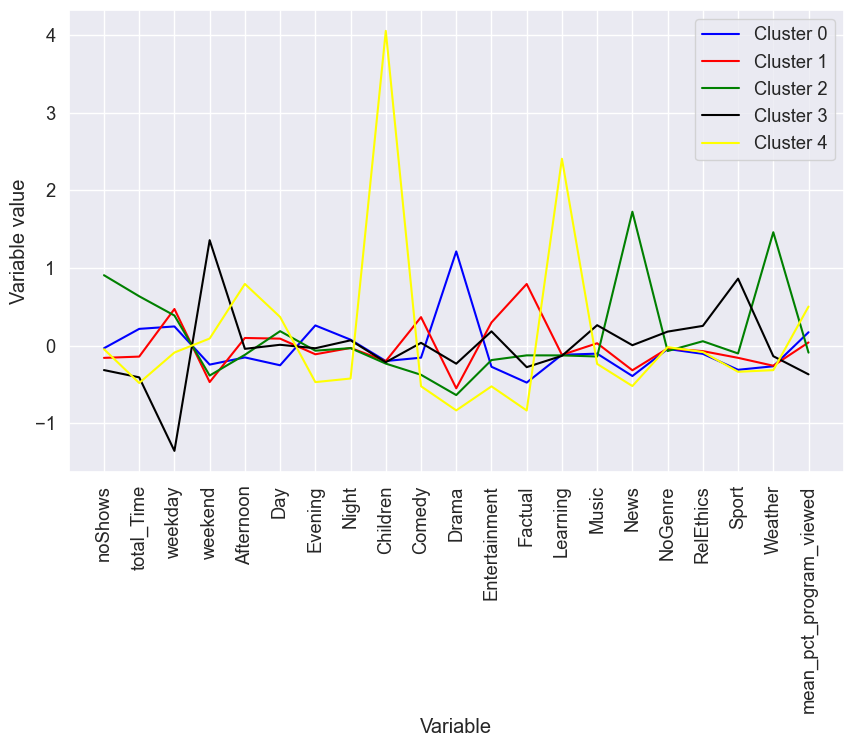

```
[1056 1159  507  726  177]
```

```python
# K=5
# Run KMeans algo
kmeans = KMeans(n_clusters = 5, random_state = 0)
kmeans.fit(scaled_user_red.iloc[:, :-1])

# Create a DataFrame for cluster centers
cluster_centers = pd.DataFrame(kmeans.cluster_centers_, columns = scaled_user_red.columns[:21])
cluster_centers['cluster'] = np.array([0, 1, 2, 3, 4])

# Visualise cluster centers
plt.figure(figsize = (10, 6))
plt.plot(cluster_centers.columns[:21], cluster_centers.iloc[0, :21], color='blue')
plt.plot(cluster_centers.columns[:21], cluster_centers.iloc[1, :21], color='red')
plt.plot(cluster_centers.columns[:21], cluster_centers.iloc[2, :21], color='green')
plt.plot(cluster_centers.columns[:21], cluster_centers.iloc[3, :21], color='black')
plt.plot(cluster_centers.columns[:21], cluster_centers.iloc[4, :21], color='yellow')
plt.xticks(rotation = 90)
plt.xlabel('Variable')
plt.ylabel('Variable value')
plt.legend(['Cluster 0', 'Cluster 1', 'Cluster 2', 'Cluster 3', 'Cluster 4'])
plt.show()

# Print cluster sizes
print(np.bincount(kmeans.labels_))
```

In the first scenario (`K=3`) we can immediately notice a cluster representing **younger watchers** (`Cluster 2`) since its center is relatively average for `noShows`, `total_Time`, `weekend` and `weekday`, and it is significantly higher than average in `Afternoon`, `Learning` and `Children`. `Cluster 0` and `Cluster 1` can also be told from one another. In fact, poeple in `Cluster 0` watch BBC for less time, they watch it mainly on the weekend and are particularly keen on `Sport` programs. Therefore, one hypothesis could be that `Cluster 0` represents the **working professionals** or people busy with work during the week who enjoy watching **Sport matches on TV** on the **weekend**, whereas `Cluster 1` represents **retired** poeple or people who have enough time to watch TV during the **weekdays** and have no particular interest in terms of genre. This representation of BBC's customer segments is solid enough but still a bit **too general** when it comes to clustering Adults.

In the second scenario (`K=4`), the cluster representing **younger watchers** turns out with the same features as the one in the first scenario. Given its **robustness**, we can conclude we have a segment of younger watchers in the pool of customers. Furthermore, the previously identified `Cluster 1` has been split into two clusters (`Cluster 2` and `Cluster 3`). `Cluster 3` has **spikes** significant enough to sharply differ from `Cluster 2`. In fact, `Cluster 3` has major spikes on `News` and `Weather` and differs from `Cluster 2` significantly with regards to `total_Time` and `noShows`. Moreover, both clusters have **significant cluster sizes**, making this second scenario more reliable.

# Comparing results of different clustering algorithms

So far we have only used `K-Means` to cluster BBC's customers. We are now going to run different types of clustering algorithms to see how differently they perform and which one best fits the case at hand.

## PAM (Partition around Medoids)

### Run the model

```python
# Import needed packages
from sklearn_extra.cluster import KMedoids

# Run KMedoids model
kmedoids = KMedoids(n_clusters=4, random_state=0)
kmedoids.fit(scaled_user_red.iloc[:, :-1])

# Print cluster sizes
print(np.bincount(kmedoids.labels_))
```

```
[ 490  842  849 1444]
```

### Visualise Centers

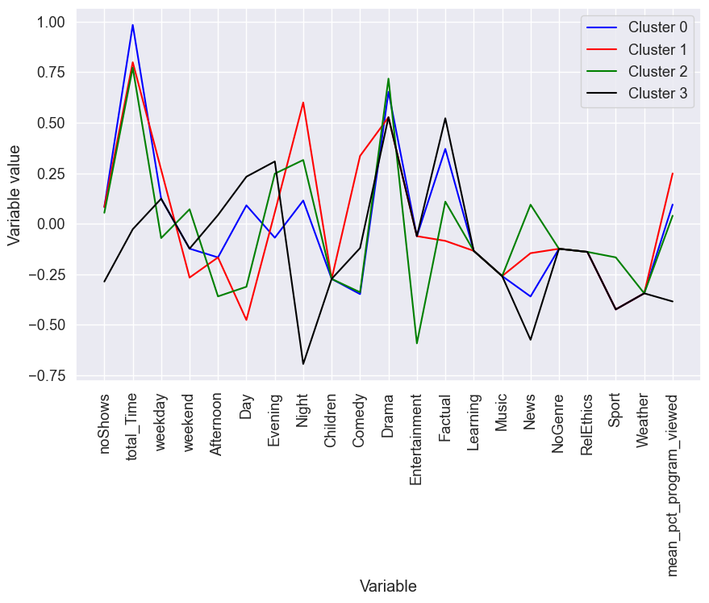

```python
# Create a DataFrame for medoids
cluster_medoids = pd.DataFrame(scaled_user_red.iloc[kmedoids.medoid_indices_, :], columns = scaled_user_red.columns[:21])
cluster_medoids['cluster'] = np.array([0, 1, 2, 3])

# Visualise cluster medoids
plt.figure(figsize = (10, 6))
plt.plot(cluster_medoids.columns[:21], cluster_medoids.iloc[0, :21], color='blue')
plt.plot(cluster_medoids.columns[:21], cluster_medoids.iloc[1, :21], color='red')
plt.plot(cluster_medoids.columns[:21], cluster_medoids.iloc[2, :21], color='green')
plt.plot(cluster_medoids.columns[:21], cluster_medoids.iloc[3, :21], color='black')
plt.xticks(rotation = 90)
plt.xlabel('Variable')
plt.ylabel('Variable value')
plt.legend(['Cluster 0', 'Cluster 1', 'Cluster 2', 'Cluster 3'])
plt.show()
```

### Visualise clusters with PCA

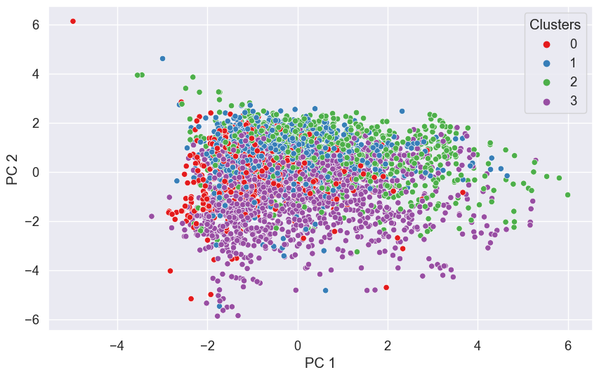

```python
# Add new labels to dataset
scaled_user_red['cluster'] = kmedoids.labels_

# Run PCA
pca = PCA(n_components = 2)
pca.fit(scaled_user_red.iloc[:, :-1])
X_pca = pca.transform(scaled_user_red.iloc[:, :-1])
X_pca = {'PC 1': X_pca[:, 0], 'PC 2': X_pca[:, 1], 'cluster': scaled_user_red.cluster}
X_pca = pd.DataFrame(X_pca)

# Plotting clusters along 2 PCs
plt.figure(figsize=(10, 6))
sns.scatterplot(data=X_pca, x='PC 1', y='PC 2', hue='cluster', palette='Set1')

# Add labels and legend
plt.xlabel('PC 1')
plt.ylabel('PC 2')
plt.legend(title='Clusters')

# Show the plot
plt.show()
```

We are now going to produce the same visualisations for the **Hierarchical clustering** and compare all the methods we used so far.

## Hierarchical clustering

### Run the model

```python
# Import needed packages
from sklearn.cluster import AgglomerativeClustering

# Run H-clustering model
h_clust = AgglomerativeClustering(n_clusters=4, affinity='euclidean', linkage='ward')
h_clust.fit(scaled_user_red.iloc[:, :-1])

# Print cluster sizes
print(np.bincount(h_clust.labels_))
```

```
[ 374 2518  532  201]
```

### Visualising Dendogram

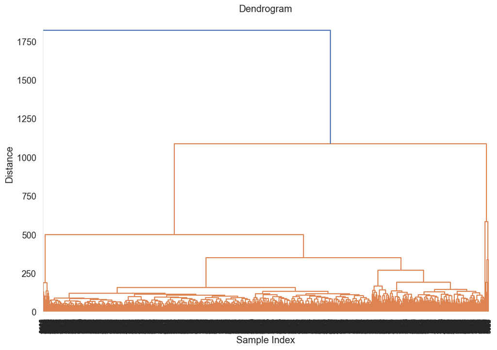

```python
# Import needed packages
from scipy.cluster.hierarchy import dendrogram
from sklearn.metrics import pairwise_distances
from scipy.cluster.hierarchy import linkage

# Compute distance_matrix
distance_matrix = pairwise_distances(scaled_user_red.iloc[:,:-1])
linkage_matrix = linkage(distance_matrix, method='complete')

# Plot dendogram
plt.figure(figsize=(12, 8))
dendrogram(linkage_matrix, labels=None, leaf_font_size=10)
plt.xlabel('Sample Index')
plt.ylabel('Distance')
plt.title('Dendrogram')
plt.show()
```

### Visualise Centers

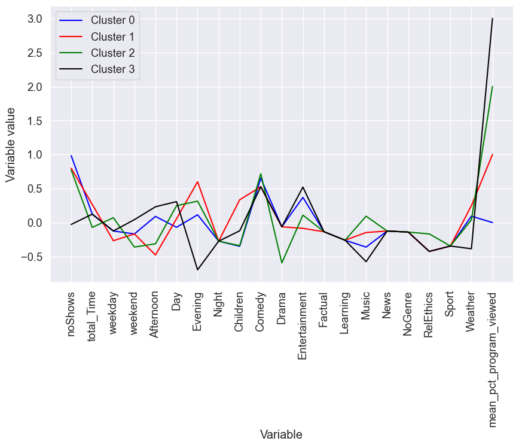

```python
# Adding clusters from h_clust to dataset
scaled_user_red['cluster'] = h_clust.labels_

# Grouping by clusters
cluster_centers = scaled_user_red.groupby('cluster').agg('mean').reset_index()

# Plotting cluster centers
plt.figure(figsize = (10, 6))
plt.plot(cluster_centers.columns[1:], cluster_medoids.iloc[0, 1:], color='blue')
plt.plot(cluster_centers.columns[1:], cluster_medoids.iloc[1, 1:], color='red')
plt.plot(cluster_centers.columns[1:], cluster_medoids.iloc[2, 1:], color='green')
plt.plot(cluster_centers.columns[1:], cluster_medoids.iloc[3, 1:], color='black')
plt.xticks(rotation = 90)
plt.xlabel('Variable')
plt.ylabel('Variable value')
plt.legend(['Cluster 0', 'Cluster 1', 'Cluster 2', 'Cluster 3'])
plt.show()
```

### Visualising clusters with PCA

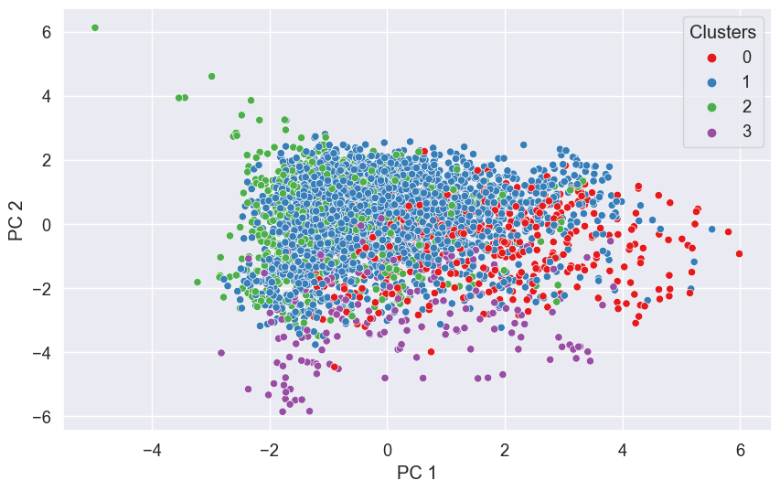

```python
# Run PCA
pca = PCA(n_components = 2)
pca.fit(scaled_user_red.iloc[:, :-1])
X_pca = pca.transform(scaled_user_red.iloc[:, :-1])
X_pca = {'PC 1': X_pca[:, 0], 'PC 2': X_pca[:, 1], 'cluster': scaled_user_red.cluster}
X_pca = pd.DataFrame(X_pca)

# Plotting clusters along 2 PCs
plt.figure(figsize=(10, 6))
sns.scatterplot(data=X_pca, x='PC 1', y='PC 2', hue='cluster', palette='Set1')

# Add labels and legend
plt.xlabel('PC 1')
plt.ylabel('PC 2')
plt.legend(title='Clusters')

# Show the plot
plt.show()
```

As shown by the cluster sizes, PCA visualisations and Centers Analysis, the two methods lead to significantly different results. First of all, with H-clustering the vast majority of observations is concentrated in one cluster, whereas observations are more evenly distributed when using PAM. Furthermore, PAM leads to a worse "separation" of the clusters compared to H-clust, as is possible to notice in the PCA visualisation. In addition, there seem to be significant differences in the cluster centers/medoids. In fact, we can notice the sharpest differences in `total_Time`, `Day`, `Night`, `Comedy`, `Factual`, `Entertainment` and `Music`. All the mentioned variables play sharply different roles in separating clusters in the two scenarios.

Both K-Medoids and H-clustering also differ sharply from K-Means. K-Medoids is the method that gets closer to K-Means, even though the cluster sizes are more evenly set in K-Medoids and there are still significant differences in the cluster centers. Furthermore, it is important to highlight that centers in K-Medoids are much **less sensitive to outliers**, as they show a much lower variability along every dimension.

**K-Medoids** gives clusters with more similar sizes. However, as already stated, the differences in the cluster centers are significant. However, we do not feel this is an evidence strong enough to suggest that there might not be 4 clusters in the sample of customers. We are now going to gather an additional piece of evidence to stress-test our decision's robustness.

# Subsample check

We will try to reinforce our conclusions and verify that they are not due to chance by dividing the data into two equal parts. We will use K-means clustering, fixing the number of clusters to 4, in these two data sets separately. If we get similar looking clusters, we can rest assured that our conclusions are robust. If not, we might want to reconsider our decision.

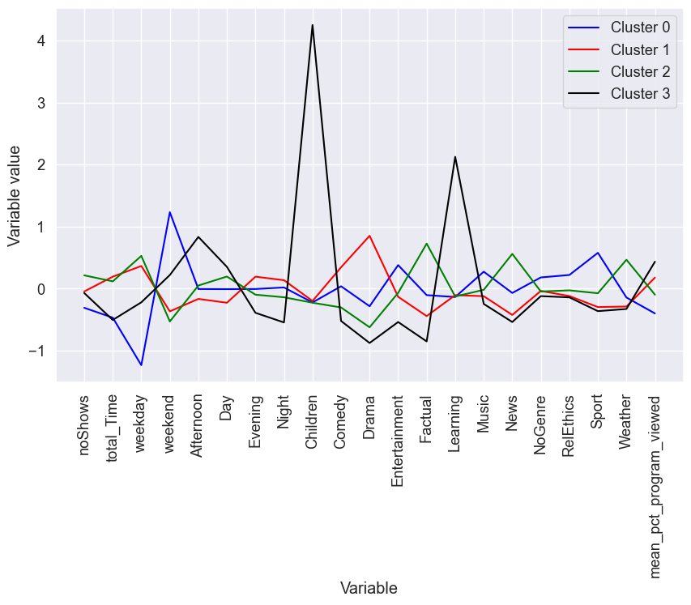

```
[422 667 632  91]
```

```python
# Split dataset
from sklearn.model_selection import train_test_split
data_train, data_test = train_test_split(scaled_user_red.iloc[:,:-1], test_size=0.5, random_state=42)

# Run on train
kmeans = KMeans(n_clusters = 4, random_state = 42)
kmeans.fit(data_train)

# Create a DataFrame for cluster centers
cluster_centers = pd.DataFrame(kmeans.cluster_centers_, columns = scaled_user_red.columns[:21])
cluster_centers['cluster'] = np.array([0, 1, 2, 3])

# Visualise cluster centers
plt.figure(figsize = (10, 6))
plt.plot(cluster_centers.columns[:21], cluster_centers.iloc[0, :21], color='blue')
plt.plot(cluster_centers.columns[:21], cluster_centers.iloc[1, :21], color='red')
plt.plot(cluster_centers.columns[:21], cluster_centers.iloc[2, :21], color='green')
plt.plot(cluster_centers.columns[:21], cluster_centers.iloc[3, :21], color='black')
plt.xticks(rotation = 90)
plt.xlabel('Variable')
plt.ylabel('Variable value')
plt.legend(['Cluster 0', 'Cluster 1', 'Cluster 2', 'Cluster 3'])
plt.show()

# Print cluster sizes
print(np.bincount(kmeans.labels_))
```

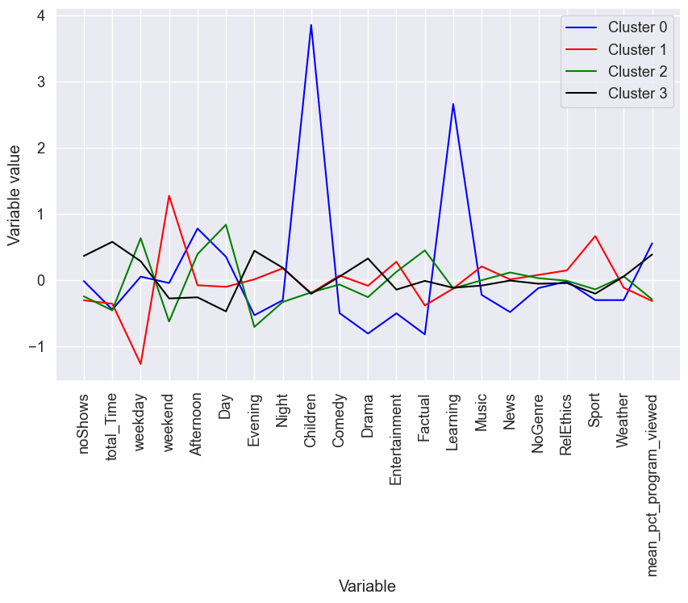

```
[ 86 447 478 802]
```

```python
# Run on test
kmeans = KMeans(n_clusters = 4, random_state = 42)
kmeans.fit(data_test)

# Create a DataFrame for cluster centers
cluster_centers = pd.DataFrame(kmeans.cluster_centers_, columns = scaled_user_red.columns[:21])
cluster_centers['cluster'] = np.array([0, 1, 2, 3])

# Visualise cluster centers
plt.figure(figsize = (10, 6))
plt.plot(cluster_centers.columns[:21], cluster_centers.iloc[0, :21], color='blue')
plt.plot(cluster_centers.columns[:21], cluster_centers.iloc[1, :21], color='red')
plt.plot(cluster_centers.columns[:21], cluster_centers.iloc[2, :21], color='green')
plt.plot(cluster_centers.columns[:21], cluster_centers.iloc[3, :21], color='black')
plt.xticks(rotation = 90)
plt.xlabel('Variable')
plt.ylabel('Variable value')
plt.legend(['Cluster 0', 'Cluster 1', 'Cluster 2', 'Cluster 3'])
plt.show()

# Print cluster sizes
print(np.bincount(kmeans.labels_))
```

# Conclusions

As shown in the two charts and in the array displaying the sizes of all clusters, we can conclude our hypothesis of 4 clusters in the population is quite **robust**. Firstly, the proportion of the cluster sizes is approximately the same in both cases, with the cluster representing **young watchers** being the smallest one, the one representing **Sport-aficionado working professionals** being the second smallest (including approximately 25% of all observations), the one representing **retired Drama aficionados** being the biggest (including approximately 40-45% of all observations) and the one representing **retired News & Weather** programs watchers being the second biggest (including approximately 30-35% of all observations).

Even though the Centers Analysis might not show the same distinction in the center spikes that was clear in the K-Means run on the entire dataset, overall we believe that the consistency in the cluster sizes, the robustness of the fourth cluster in the scenario comparison (`K=4` and `K=5`) and the recurrence of many of the spikes seen before in both the testing and training datasets all overweigh the pieces of evidence countering this conclusion.

One of the main assumptions we are making is that **outliers** in this dataset are not far enough from the mean to significantly decrease the reliability of the results obtained using K-Means instead of K-Medoids. In fact, when using K-Medoids, the results obtained (especially with regards to the cluster centers) are **significantly different** from the ones obtained in K-Means. One way we could check the robustness of our assumption is to **run K-Medoids** specifying **different numbers of clusters** to see whether the results are still significantly different from the ones obtained using K-Means.

In conclusion, the results of this project could benefit BBC in multiple ways. For instance, BBC could leverage the information on the clusters and the data on its customers to **tailor the marketing strategy** to the specific kind of user at hand. In addition, the results of this cluster analysis could be used by BBC to make a **profitability analysis** of each customer segment, thus understanding which is better to prioritise in case resources must be more efficiently allocated.